# Build Analysis Datasets: Person-Period Rows + Cluster Labels (fallback_emo_ace)

Sam A. Sievertsen

2026-10-01

## 1. Create Helper Functions to Use in Cleaning Data for Statistical Analyses

Utility functions to standardize dataset construction. We a) extract stable cluster labels from the chosen k-prototype solution, b) complete the ID by assessment timepoint grid, c) convert wave statuses into person-period intervals with a first-onset event coded at the interval end while excluding baseline-positive person-time, and d) join safely with row-count warnings

```r
## 1. Establish helper functions for creating analysis ready data ##

#1.1 Extract participant_id from kproto$data (rownames preferred), orienting labels by content rather than raw cluster number
#1.1.0 kproto numbers clusters arbitrarily; clusters are relabelled C1 to Ck in ASCENDING order of mean CBCL dysregulation
#      profile raw sum, so at k = 2 C1 is always the lower-risk reference and C2 the higher-risk group; this reproduces the
#      submitted analysis's data coding, which every downstream model uses (reference = C1; contrasts = C2 vs C1)
get_cluster_labels <- function(kp, k_value, orient_df) {
  dat <- as.data.frame(kp$data)

  #1.1.1 Try rownames of the kp obj first
  if (!is.null(rownames(dat)) && all(nzchar(rownames(dat)))) {
    ids <- rownames(dat)
  } else if ("participant_id" %in% names(dat)) {
    ids <- as.character(dat$participant_id)
  } else {
    stop("Could not infer participant_id for cluster labels from kproto$data. ",
         "Ensure rownames carry IDs or participant_id is a column.")
  }

  #1.1.2 Rank raw clusters by ascending mean dysregulation profile raw sum, and relabel them C1 to Ck in that order
  dp <- orient_df$cbcl_dp_raw_sum[match(as.character(ids), as.character(orient_df$participant_id))]
  if (anyNA(dp)) stop("cbcl_dp_raw_sum unavailable for some clustered participants; cannot orient labels")
  raw_means <- tapply(dp, kp$cluster, mean)
  raw_order <- as.integer(names(sort(raw_means, decreasing = FALSE)))
  stopifnot(length(raw_order) == k_value)
  cl <- factor(paste0("C", match(kp$cluster, raw_order)), levels = paste0("C", seq_len(k_value)))

  #1.1.3 Return labels plus the raw-to-oriented mapping for provenance
  list(
    labels = tibble(participant_id = as.character(ids), cluster = cl),
    orientation = tibble(
      oriented_cluster = paste0("C", seq_len(k_value)),
      raw_cluster = raw_order,
      n = as.integer(table(kp$cluster)[as.character(raw_order)]),
      mean_cbcl_dp_raw_sum = as.numeric(raw_means[as.character(raw_order)]))
  )
}

#1.2 Ensure (id, session) grid is as expected and keep original values
complete_id_wave <- function(df) {
  df %>%
    complete(
      participant_id,
      session_id = factor(session_id, levels = levels(df$session_id))
    )
}

#1.3 Build person-period intervals from assessment wave-states
#    - status_col: 0/1/NA status at each wave
#    - returns one row per interval: (start_wave -> end_wave), event is first-onset at end_wave
make_person_period <- function(df, status_col, baseline_wave, start_wave_cut) {

  #1.3.1 Precompute the index of the modeling start wave
  start_cut_idx <- which(levels(df$session_id) == start_wave_cut)
  if (length(start_cut_idx) != 1L) {
    stop("start_wave_cut must match one of the session_id factor levels.")
  }

  #1.3.2 Order df within id
  df <- df %>%
    arrange(participant_id, session_id) %>%
    group_by(participant_id) %>%
    mutate(
      status = .data[[status_col]],
      .first_wave = first(na.omit(as.character(session_id)))) %>%
    ungroup()

  #1.3.3 Collapse df to one row per (id, wave) with status
  core <- df %>%
    dplyr::select(participant_id, session_id, status) %>%
    complete_id_wave()

  #1.3.4 Derive interval ends and starts
  core <- core %>%
    group_by(participant_id) %>%
    arrange(session_id, .by_group = TRUE) %>%
    mutate(
      wave_idx = as.integer(session_id),
      start_idx = lag(wave_idx),
      start_wave = lag(session_id),
      end_wave = session_id,
      is_pos = (status == 1),
      is_obs = !is.na(status),
      ever_pos_prior = dplyr::lag(cummax(replace_na(is_pos, FALSE)), default = FALSE),
      event_end  = dplyr::case_when(
        !is_obs ~ NA_integer_,
        !ever_pos_prior & is_pos ~ 1L,
        TRUE ~ 0L),
      baseline_status = status[which(session_id == baseline_wave)][1]) %>%
    ungroup() %>%
    filter(!is.na(start_idx))

  #1.3.5 Restrict intervals to modeling start
  core <- core %>%
    filter(as.integer(end_wave) >= start_cut_idx)

  #1.3.6 Exclude all person-time once a participant has been positive at any prior assessment, baseline included
  #      (i.e., baseline-positive participants contribute no at-risk intervals, and intervals after a first onset are removed);
  #      the onset interval itself is retained with event = 1, and NA prior statuses are treated as not positive, as above
  core <- core %>%
    filter(!ever_pos_prior)

  #1.3.7 Return analysis-ready person-period rows
  core %>%
    transmute(
      participant_id,
      start_wave = fct_drop(start_wave),
      end_wave = fct_drop(end_wave),
      event = event_end,
      baseline_status = as.integer(baseline_status)
    )
}

#1.4 Perform a safe left join & warn on drops
left_join_guard <- function(x, y, by) {
  before <- nrow(x)
  out <- left_join(x, y, by = by)
  after <- nrow(out)
  if (after != before) warning(glue("Row count changed in join: {before} -> {after}"))
  out
}
```

## 2. Extract Cluster Labels from Chosen k Solution

Pull participant-level cluster assignments for the requested configuration and k, recover IDs from `kproto$data` (rownames preferred), label clusters C1…Ck in ascending order of mean CBCL dysregulation profile raw sum (so C1 is always the lower-risk reference and C2 the higher-risk group at k = 2, independent of kproto’s arbitrary numbering, matching the submitted data coding), and persist to disk (with caching). Freezing labels here provides a single source of truth for downstream models and provenance

```r
## 2. Extract cluster labels for chosen k ##

#2.1 Extract content-oriented labels and the raw-to-oriented mapping
label_out <- get_cluster_labels(kp, params$k_value, risk_df)
labels_tbl <- label_out$labels

#2.2 Save (skip/overwrite logic), verifying any cached file agrees with the current fit so stale labels can never be reused
if (file.exists(lab_csv) && isFALSE(params$overwrite)) {
  message("Cluster label file exists; verifying against the current fit: ", basename(lab_csv))
  cached_tbl <- readr::read_csv(lab_csv, show_col_types = FALSE)
  if (!identical(as.character(cached_tbl$participant_id), labels_tbl$participant_id) ||
      !identical(as.character(cached_tbl$cluster), as.character(labels_tbl$cluster))) {
    stop("Cached ", basename(lab_csv), " disagrees with the current fit; rerun with overwrite = TRUE if intended")
  }
} else {
  readr::write_csv(labels_tbl, lab_csv)
}
readr::write_csv(label_out$orientation, orient_csv)

#2.3 Quick check: oriented cluster sizes and the mapping from raw kproto cluster numbers
label_out$orientation
```

```
# A tibble: 2 × 4
  oriented_cluster raw_cluster     n mean_cbcl_dp_raw_sum
  <chr>                  <int> <int>                <dbl>
1 C1                         1  6969                 5.92
2 C2                         2  2071                16.7
```

## 3. Merge Cluster Labels from Chosen k Solution to Outcome Data

Subset the wrangled outcome fields to just those needed for analysis and attach one cluster label per participant. Waves remain ordered factors so longitudinal structure and interval building are preserved. This aligns clusters with outcomes before any modeling transforms

```r
## 3. Merge cluster labels to outcomes (baseline carried separately) ##

#3.1 Keep only needed outcome columns
needed_cols <- c("participant_id","session_id",
                 "bipolar_I","bipolar_II","bd_nos","any_bsd",
                 "si_passive","si_active","sa","nssi")

#3.2 Select relevant outcome columns for analysis
out_core <- out_df %>%
  dplyr::select(any_of(needed_cols))

#3.3 Attach cluster labels (one per participant)
out_core <- left_join_guard(out_core, labels_tbl, by = "participant_id")
```

## 4. Build the Person-Period Structured Outcome Data for Analysis

Construct discrete-time survival datasets. For BD and suicidality outcomes we form intervals (00A->02A, 02A->04A, 04A->06A), define events as the first observed 1 at the interval end, and drop at-risk time for baseline-positive cases to prevent leakage. Suicidality intervals are optionally capped at Y4 given youth don’t report past diagnoses past that timepoint on the KSADS, and suicidality rows also receive time-varying BD indicators (start/end) to support temporal precedence tests further downstream.

Also, we create both a non-filtered and filtered version of each of the datasets where relevant (e.g., the suicidality data is created both across the whole sample and nested within participants who ever endorse BD)

```r
## 4. Build person-period datasets ##

#4.1 BD outcomes: person-period from 02A onward; event = first-onset
bd_pp <- bind_rows(

  #4.1.1 BD-I person-period
  make_person_period(out_core, "bipolar_I", params$baseline_wave, params$start_wave) %>% mutate(outcome = "bipolar_I"),

  #4.1.2 BD-II person-period
  make_person_period(out_core, "bipolar_II", params$baseline_wave, params$start_wave) %>% mutate(outcome = "bipolar_II"),

  #4.1.3 BD-NOS person-period
  make_person_period(out_core, "bd_nos", params$baseline_wave, params$start_wave) %>% mutate(outcome = "bd_nos"),

  #4.1.4 Any-BSD person-period
  make_person_period(out_core, "any_bsd", params$baseline_wave, params$start_wave) %>% mutate(outcome = "any_bsd")) %>%

  #4.1.5 Left join and order the BD person-period data
  left_join_guard(labels_tbl, by = "participant_id") %>%
  relocate(participant_id, start_wave, end_wave, outcome, event, cluster, baseline_status)

#4.2 Suicidality outcomes: person-period (limit to end wave if specified)
su_pp_all <- bind_rows(

  #4.2.1 SI passive person-period
  make_person_period(out_core, "si_passive", params$baseline_wave, params$start_wave) %>% mutate(outcome = "si_passive"),

  #4.2.2 SI active person-period
  make_person_period(out_core, "si_active", params$baseline_wave, params$start_wave) %>% mutate(outcome = "si_active"),

  #4.2.3 SA person-period
  make_person_period(out_core, "sa", params$baseline_wave, params$start_wave) %>% mutate(outcome = "sa"),

  #4.2.4 NSSI person-period
  make_person_period(out_core, "nssi", params$baseline_wave, params$start_wave) %>% mutate(outcome = "nssi")) %>%

  #4.2.5 Left join and order the suicidality person-period data
  left_join_guard(labels_tbl, by = "participant_id") %>%
  relocate(participant_id, start_wave, end_wave, outcome, event, cluster, baseline_status)

#4.3 Place a modifiable cap on suicidality intervals based on data collected by ABCD study
su_pp <- su_pp_all %>%
  filter(as.character(end_wave) <= params$max_suic_end_wave)

#4.4 Add time varying BD to suicidality person-period; use START for temporal precedence
#4.4.1 Construct an any_bsd df with just the participant, session, & dx info
any_bsd_df <- out_core %>%
  dplyr::select(participant_id, session_id, any_bsd)

#4.4.2 Add in a time varying (across timepoints rather) BD indicator to the suicidality data
su_pp <- su_pp %>%
  left_join_guard(any_bsd_df %>% dplyr::rename(bd_any_end = any_bsd),
                  by = c("participant_id","end_wave" = "session_id")) %>%
  left_join_guard(any_bsd_df %>% dplyr::rename(bd_any_start = any_bsd),
                  by = c("participant_id","start_wave" = "session_id"))
```

## 5. Build the Per-Assessment Timepoint Structured Outcome Data for Analysis

Create per-assessment timepoint panel data for mixed-effects/GEEs: pivot outcomes long from Y2 onward, carry baseline status for adjustment, and (for suicidality) attach BD at wave and its lag. These tables support timepoint-specific odds models and interaction testing without any interval manipulation required (hopefully)

```r
#5.1 Build BD panel per-wave data
#5.1.1 Baseline status for each BD outcome
base_bd_long <- out_core %>%
  dplyr::filter(session_id == params$baseline_wave) %>%
  tidyr::pivot_longer(
    c(bipolar_I, bipolar_II, bd_nos, any_bsd),
    names_to = "outcome", values_to = "baseline_status_bd") %>%
  dplyr::select(participant_id, outcome, baseline_status_bd)

#5.1.2 Long per-wave statuses from Y2 onward
bd_panel <- out_core %>%
  dplyr::filter(as.integer(session_id) >= match(params$start_wave, wave_levels)) %>%
  tidyr::pivot_longer(
    c(bipolar_I, bipolar_II, bd_nos, any_bsd),
    names_to = "outcome", values_to = "status") %>%
  left_join_guard(base_bd_long, by = c("participant_id","outcome")) %>%
  left_join_guard(labels_tbl, by = c("participant_id", "cluster")) %>%
  dplyr::rename(wave = session_id)

#5.2 Build suicidality panel per-wave data
#5.2.1 Baseline status for each suicidality outcome
base_su_long <- out_core %>%
  dplyr::filter(session_id == params$baseline_wave) %>%
  tidyr::pivot_longer(
    c(si_passive, si_active, sa, nssi),
    names_to = "outcome", values_to = "baseline_status_su") %>%
  dplyr::select(participant_id, outcome, baseline_status_su)

#5.2.2 Any BSD at wave + lag for time-varying covariate
bd_at_wave <- out_core %>%
  dplyr::select(participant_id, session_id, any_bsd) %>%
  dplyr::rename(wave = session_id, bd_any_wave = any_bsd) %>%
  arrange(participant_id, wave) %>%
  group_by(participant_id) %>%
  mutate(bd_any_prior = dplyr::lag(bd_any_wave)) %>%
  ungroup()

#5.2.3 Long per-wave suicidality statuses from Y2 onward
su_panel <- out_core %>%
  dplyr::filter(as.integer(session_id) >= match(params$start_wave, wave_levels)) %>%
  tidyr::pivot_longer(
    c(si_passive, si_active, sa, nssi),
    names_to = "outcome", values_to = "status") %>%
  left_join_guard(base_su_long, by = c("participant_id","outcome")) %>%
  left_join_guard(labels_tbl, by = c("participant_id", "cluster")) %>%
  dplyr::rename(wave = session_id) %>%
  left_join_guard(bd_at_wave, by = c("participant_id","wave"))

#5.3 Nested suicidality within BD cases (ever-BD subcohort)
#5.3.1 Ever-BD flag(based on any_bsd at any wave
ever_bd <- out_core %>%
  dplyr::group_by(participant_id) %>%
  dplyr::summarise(ever_bd = any(any_bsd == 1, na.rm = TRUE), .groups = "drop")

#5.3.2 Create suicidality person-period and panel data restricted to ever-BD participants
su_bd_pp <- su_pp %>% left_join_guard(ever_bd, by = "participant_id") %>% dplyr::filter(ever_bd)
su_bd_panel <- su_panel  %>% left_join_guard(ever_bd, by = "participant_id") %>% dplyr::filter(ever_bd)
```

## 6. Merge Covariate Data Into Outcome Data

Normalize and merge covariates: age (per wave), sex, site, family ID, and race/ethnicity (though consider whether the latter will be used in any capacity very carefully). For person-period data we attach age at start and end to compute mid-interval age, then derive centered variants (grand-mean, within-person, and between-person components). The same centering is created for per-wave age

```r
## 6. Merge time-varying covariates (age), and static (sex, site, family ID, race) ##

#6.1 Load and normalize covariates from the raw file
if (!is.null(params$covariates_file) && file.exists(params$covariates_file)) {
  cov_raw <- readr::read_csv(params$covariates_file, show_col_types = FALSE)

  #6.1.1.1 Select the relevant ABCD columns
  cov_df <- cov_raw %>%
    dplyr::select(
      participant_id,
      session_id,
      age_raw = ab_g_dyn__visit_age,
      sex_raw = ab_g_stc__cohort_sex,
      site_raw = ab_g_dyn__design_site,
      fam_raw = ab_g_stc__design_id__fam,
      race_ethnicity = ab_g_stc__cohort_ethnrace__meim) %>%
    mutate(
      participant_id = as.character(participant_id),
      session_id = factor(session_id, levels = wave_levels),

      #6.1.1.1.1 Coerce data types safely
      age_raw = suppressWarnings(as.numeric(age_raw)),
      fam_raw = as.character(fam_raw),

      #6.1.1.1.2 Clean sex to Male/Female if possible, else factorize as-is
      sex = case_when(
        sex_raw %in% c(1, "1", "M", "Male") ~ "Male",
        sex_raw %in% c(2, "2", "F", "Female") ~ "Female",
        sex_raw %in% c(3, "3", "Other", "Intersex") ~ "Intersex",
        TRUE ~ as.character(sex_raw)),

      #6.1.1.1.3 Clean site to factor with readable labels
      site_factor = forcats::fct_inorder(paste0("Site_", as.character(site_raw))),

      #6.1.1.1.4 Establish race-ethnicity as factor but keep original labels
      race_ethnicity = factor(as.character(race_ethnicity))) %>%

    #6.1.1.2 Keep exactly one row per id x wave
    arrange(participant_id, session_id) %>%
    dplyr::distinct(participant_id, session_id, .keep_all = TRUE) %>%

    #6.1.1.3 Establish final renames to use in joins
    dplyr::rename(age = age_raw, family_id = fam_raw) %>%
    dplyr::select(participant_id, session_id, age, sex, site_factor, family_id, race_ethnicity)

  #6.1.2 Create a helper function to attach end-wave covariates + start age, then derive centered ages
  add_cov <- function(pp) {

    #6.1.2.1 Join covariates at END of interval
    pp1 <- pp %>%
      left_join_guard(
        cov_df,
        by = c("participant_id" = "participant_id", "end_wave" = "session_id")) %>%
      dplyr::rename(age_end = age)

    #6.1.2.2 Join age at START of interval (for midpoint)
    pp2 <- pp1 %>%
      left_join_guard(
        cov_df %>% dplyr::select(participant_id, session_id, age) %>%
          dplyr::rename(age_start = age),
        by = c("participant_id" = "participant_id", "start_wave" = "session_id"))

    #6.1.2.3 Derive age midpoint and centered variants
    pp3 <- pp2 %>%
      mutate(
        interval_index = as.integer(end_wave),
        age_mid = dplyr::coalesce((age_start + age_end) / 2, age_end, age_start)) %>%

      #6.1.2.3.1 Grand-mean center age across all person-period rows with age_mid
      mutate(age_mid_gmc = age_mid - mean(age_mid, na.rm = TRUE)) %>%

      #6.1.2.3.2 Person-mean center age within-person
      group_by(participant_id) %>%
      mutate(
        age_mid_person_mean = mean(age_mid, na.rm = TRUE),
        age_mid_cwc = age_mid - age_mid_person_mean) %>%
      ungroup() %>%

      #6.1.2.3.3 Calculate between-person age (person mean - grand mean)
      mutate(
        age_mid_between = age_mid_person_mean - mean(age_mid, na.rm = TRUE)
      )

    #6.1.2.4 Return a modified version of the person-period data to introduce to the rest of the outcome data
    pp3
  }

  #6.1.3 Apply to BD and suicidality person-period datasets
  bd_pp <- add_cov(bd_pp)
  su_pp <- add_cov(su_pp)
  su_bd_pp <- add_cov(su_bd_pp)

} else {
  message("No covariates_file provided or found; proceeding without age/sex/site/family/race covariates.")
}

#6.2 Attach covariates to panel datasets per-wave
#6.2.1 Check if the covariates dataframe exists before proceeding
if (exists("cov_df")) {

  #6.2.2 Define a function to add covariates and create centering variables for panel data
  add_cov_panel <- function(pn) {
    out <- pn %>%
      left_join_guard(
        cov_df,
        by = c("participant_id" = "participant_id", "wave" = "session_id")) %>%
      dplyr::rename(age_wave = age)

    #6.2.3 Join the panel data with covariates, matching on participant ID and wave/session
    out %>%
      mutate(
        age_wave_gmc = age_wave - mean(age_wave, na.rm = TRUE)) %>%
      group_by(participant_id) %>%
      mutate(
        age_wave_person_mean = mean(age_wave, na.rm = TRUE),
        age_wave_cwc = age_wave - age_wave_person_mean) %>%
      ungroup() %>%
      mutate(
        age_wave_between = age_wave_person_mean - mean(age_wave, na.rm = TRUE))
  }

  #6.2.4 Apply the covariate addition function to both panel per-wave datasets
  bd_panel <- add_cov_panel(bd_panel)
  su_panel <- add_cov_panel(su_panel)
  su_bd_panel <- add_cov_panel(su_bd_panel)
}
```

## 7. Save Output Data

Write analysis-ready datasets (person-period and per-wave for BD and suicidality) to CSV and RDS using consistent filenames and overwrite guards

```r
## 7. Save outputs (with overwrite rules) ##

#7.1 Save person-period data
#7.1.1 BD person-period
if ((file.exists(bd_rds) || file.exists(bd_csv)) && isFALSE(params$overwrite)) {
  message("BD person-period exists; skipping write.")
} else {
  readr::write_csv(bd_pp, bd_csv)
  saveRDS(bd_pp, bd_rds)
}

#7.1.2 Suicidality person-period
if ((file.exists(su_rds) || file.exists(su_csv)) && isFALSE(params$overwrite)) {
  message("Suicidality person-period exists; skipping write.")
} else {
  readr::write_csv(su_pp, su_csv)
  saveRDS(su_pp, su_rds)
}

#7.1.3 Suicidality person-period restricted to BD cases
if ((file.exists(su_bd_rds) || file.exists(su_bd_csv)) && isFALSE(params$overwrite)) {
  message("Nested suicidality person-period exists; skipping write.")
} else {
  readr::write_csv(su_bd_pp, su_bd_csv)
  saveRDS(su_bd_pp, su_bd_rds)
}

#7.2 Save panel per-wave datasets
#7.2.1 BD panel per-wave data
if ((file.exists(bd_panel_rds) || file.exists(bd_panel_csv)) && isFALSE(params$overwrite)) {
  message("BD panel exists; skipping write.")
} else {
  readr::write_csv(bd_panel, bd_panel_csv); saveRDS(bd_panel, bd_panel_rds)
}

#7.2.2 Suicidality panel per-wave data
if ((file.exists(su_panel_rds) || file.exists(su_panel_csv)) && isFALSE(params$overwrite)) {
  message("Suicidality panel exists; skipping write.")
} else {
  readr::write_csv(su_panel, su_panel_csv); saveRDS(su_panel, su_panel_rds)
}

#7.2.3 Suicidality panel per-wave data restricted to BD cases
if ((file.exists(su_bd_panel_rds) || file.exists(su_bd_panel_csv)) && isFALSE(params$overwrite)) {
  message("Nested suicidality panel exists; skipping write.")
} else {
  readr::write_csv(su_bd_panel, su_bd_panel_csv); saveRDS(su_bd_panel, su_bd_panel_rds)
}
```

## 8. Perform Checks that the Outcome Data was Generated as Expected

Run dynamic QC:

- ID/coverage integrity,
- one-onset-per-subject rule,
- baseline-exclusion enforcement,
- parity between panel-detected onsets and person-period events,
- covariate missingness,
- age monotonicity,
- and cluster label presence post-merge

We also include quick incidence-by-wave plots and a roll-up table so any logic errors will hopefully be caught before modeling

8.1 ID/Shape Integrity

| Check | Value |
| --- | --- |
| N participants with cluster labels | 9040 |
| N participants with outcome rows | 11868 |
| Labels not found in outcome | 0 |
| Outcome IDs missing labels | 2828 |

8.1A Dataset sizes (pre-filter)

| Dataset | Rows | IDs |
| --- | --- | --- |
| BD person-period (pre-filter) | 139751 | 11868 |
| Suicidality person-period (pre-filter) | 85828 | 11780 |
| BD panel (pre-filter) | 103072 | 11192 |
| Suicidality panel (pre-filter) | 103072 | 11192 |

8.2.1 BD person-period (pre-filter): one-onset rule

| n_subjects | n_multi_onsets | n_rows_after_onset | n_with_event_NA |
| --- | --- | --- | --- |
| 46968 | 0 | 0 | 28149 |

8.2.2 Suicidality person-period (pre-filter): one-onset rule

| n_subjects | n_multi_onsets | n_rows_after_onset | n_with_event_NA |
| --- | --- | --- | --- |
| 43963 | 0 | 0 | 9516 |

8.2.3 Baseline-positive excluded from at-risk time (pre-filter)

| Dataset | BaselineAtRiskViolations |
| --- | --- |
| BD person-period (pre-filter) | 0 |
| Suicidality person-period (pre-filter) | 0 |

8.2.4 BD (pre-filter): panel vs person-period - onsets & percentages

| outcome | wave | onsets_panel | at_risk_panel | perc_onset_panel | n_panel_obs | prev_panel | pos_panel | onsets_pp | n_pp_obs | perc_onset_pp | diff_onsets |
| --- | --- | --- | --- | --- | --- | --- | --- | --- | --- | --- | --- |
| any_bsd | ses-02A | 126 | 10769 | 0.0117003 | 10972 | 0.0130332 | 143 | 126 | 10769 | 0.0117003 | 0 |
| any_bsd | ses-04A | 271 | 9102 | 0.0297737 | 9369 | 0.0312733 | 293 | 271 | 9102 | 0.0297737 | 0 |
| any_bsd | ses-06A | 163 | 4796 | 0.0339867 | 5038 | 0.0373164 | 188 | 163 | 4796 | 0.0339867 | 0 |
| bd_nos | ses-02A | 81 | 10846 | 0.0074682 | 10972 | 0.0079293 | 87 | 81 | 10846 | 0.0074682 | 0 |
| bd_nos | ses-04A | 111 | 9207 | 0.0120560 | 9369 | 0.0125947 | 118 | 111 | 9207 | 0.0120560 | 0 |
| bd_nos | ses-06A | 87 | 4922 | 0.0176757 | 5038 | 0.0180627 | 91 | 87 | 4922 | 0.0176757 | 0 |
| bipolar_I | ses-02A | 64 | 10880 | 0.0058824 | 10972 | 0.0062887 | 69 | 64 | 10880 | 0.0058824 | 0 |
| bipolar_I | ses-04A | 128 | 9245 | 0.0138453 | 9369 | 0.0141958 | 133 | 128 | 9245 | 0.0138453 | 0 |
| bipolar_I | ses-06A | 70 | 4918 | 0.0142334 | 5038 | 0.0148869 | 75 | 70 | 4918 | 0.0142334 | 0 |
| bipolar_II | ses-02A | 28 | 10944 | 0.0025585 | 10972 | 0.0026431 | 29 | 28 | 10944 | 0.0025585 | 0 |
| bipolar_II | ses-04A | 45 | 9324 | 0.0048263 | 9369 | 0.0048031 | 45 | 45 | 9324 | 0.0048263 | 0 |
| bipolar_II | ses-06A | 25 | 4994 | 0.0050060 | 5038 | 0.0051608 | 26 | 25 | 4994 | 0.0050060 | 0 |

8.2.5 Suicidality (pre-filter): panel vs person-period - onsets & percentages

| outcome | wave | onsets_panel | at_risk_panel | perc_onset_panel | n_panel_obs | prev_panel | pos_panel | onsets_pp | n_pp_obs | perc_onset_pp | diff_onsets |
| --- | --- | --- | --- | --- | --- | --- | --- | --- | --- | --- | --- |
| nssi | ses-02A | 549 | 9990 | 0.0549550 | 10972 | 0.0746445 | 819 | 549 | 9990 | 0.0549550 | 0 |
| nssi | ses-04A | 769 | 8062 | 0.0953858 | 9369 | 0.1274416 | 1194 | 769 | 8062 | 0.0953858 | 0 |
| sa | ses-02A | 168 | 10801 | 0.0155541 | 10972 | 0.0202333 | 222 | 168 | 10801 | 0.0155541 | 0 |
| sa | ses-04A | 303 | 9085 | 0.0333517 | 9369 | 0.0420536 | 394 | 303 | 9085 | 0.0333517 | 0 |
| si_active | ses-02A | 642 | 10166 | 0.0631517 | 10972 | 0.0865840 | 950 | 642 | 10166 | 0.0631517 | 0 |
| si_active | ses-04A | 763 | 8154 | 0.0935737 | 9369 | 0.1379016 | 1292 | 763 | 8154 | 0.0935737 | 0 |
| si_passive | ses-02A | 739 | 9709 | 0.0761149 | 10972 | 0.1129238 | 1239 | 739 | 9709 | 0.0761149 | 0 |
| si_passive | ses-04A | 721 | 7678 | 0.0939047 | 9369 | 0.1510300 | 1415 | 721 | 7678 | 0.0939047 | 0 |

8.2.6 Suicidality (pre-filter, ever-BD): panel vs person-period - onsets & percentages

| outcome | wave | onsets_panel | at_risk_panel | perc_onset_panel | n_panel_obs | prev_panel | pos_panel | onsets_pp | n_pp_obs | perc_onset_pp | diff_onsets |
| --- | --- | --- | --- | --- | --- | --- | --- | --- | --- | --- | --- |
| nssi | ses-02A | 98 | 600 | 0.1633333 | 751 | 0.2103862 | 158 | 98 | 600 | 0.1633333 | 0 |
| nssi | ses-04A | 120 | 463 | 0.2591793 | 681 | 0.3303965 | 225 | 120 | 463 | 0.2591793 | 0 |
| sa | ses-02A | 42 | 704 | 0.0596591 | 751 | 0.0812250 | 61 | 42 | 704 | 0.0596591 | 0 |
| sa | ses-04A | 71 | 606 | 0.1171617 | 681 | 0.1439060 | 98 | 71 | 606 | 0.1171617 | 0 |
| si_active | ses-02A | 99 | 588 | 0.1683673 | 751 | 0.2463382 | 185 | 99 | 588 | 0.1683673 | 0 |
| si_active | ses-04A | 122 | 455 | 0.2681319 | 681 | 0.3715125 | 253 | 122 | 455 | 0.2681319 | 0 |
| si_passive | ses-02A | 106 | 537 | 0.1973929 | 751 | 0.3022636 | 227 | 106 | 537 | 0.1973929 | 0 |
| si_passive | ses-04A | 101 | 406 | 0.2487685 | 681 | 0.3817915 | 260 | 101 | 406 | 0.2487685 | 0 |

8.3.1 Covariate missingness (person-period, pre)

| Dataset | Variable | N | Missing | PctMissing |
| --- | --- | --- | --- | --- |
| BD person-period (pre-filter) | age_start | 139751 | 11628 | 8.32 |
| BD person-period (pre-filter) | age_end | 139751 | 20644 | 14.77 |
| BD person-period (pre-filter) | age_mid | 139751 | 7965 | 5.70 |
| BD person-period (pre-filter) | age_mid_gmc | 139751 | 7965 | 5.70 |
| BD person-period (pre-filter) | age_mid_cwc | 139751 | 7965 | 5.70 |
| BD person-period (pre-filter) | sex | 139751 | 20604 | 14.74 |
| BD person-period (pre-filter) | site_factor | 139751 | 20604 | 14.74 |
| BD person-period (pre-filter) | family_id | 139751 | 20604 | 14.74 |
| BD person-period (pre-filter) | race_ethnicity | 139751 | 20620 | 14.75 |
| Suicidality person-period (pre-filter) | age_start | 85828 | 3269 | 3.81 |
| Suicidality person-period (pre-filter) | age_end | 85828 | 10631 | 12.39 |
| Suicidality person-period (pre-filter) | age_mid | 85828 | 2580 | 3.01 |
| Suicidality person-period (pre-filter) | age_mid_gmc | 85828 | 2580 | 3.01 |
| Suicidality person-period (pre-filter) | age_mid_cwc | 85828 | 2580 | 3.01 |
| Suicidality person-period (pre-filter) | sex | 85828 | 10615 | 12.37 |
| Suicidality person-period (pre-filter) | site_factor | 85828 | 10615 | 12.37 |
| Suicidality person-period (pre-filter) | family_id | 85828 | 10615 | 12.37 |
| Suicidality person-period (pre-filter) | race_ethnicity | 85828 | 10622 | 12.38 |

8.3.2 Covariate missingness (panel, pre)

| Dataset | Variable | N | Missing | PctMissing |
| --- | --- | --- | --- | --- |
| BD panel (pre-filter) | age_wave | 103072 | 60 | 0.06 |
| BD panel (pre-filter) | age_wave_gmc | 103072 | 60 | 0.06 |
| BD panel (pre-filter) | age_wave_cwc | 103072 | 60 | 0.06 |
| BD panel (pre-filter) | sex | 103072 | 60 | 0.06 |
| BD panel (pre-filter) | site_factor | 103072 | 60 | 0.06 |
| BD panel (pre-filter) | family_id | 103072 | 60 | 0.06 |
| BD panel (pre-filter) | race_ethnicity | 103072 | 72 | 0.07 |
| Suicidality panel (pre-filter) | age_wave | 103072 | 60 | 0.06 |
| Suicidality panel (pre-filter) | age_wave_gmc | 103072 | 60 | 0.06 |
| Suicidality panel (pre-filter) | age_wave_cwc | 103072 | 60 | 0.06 |
| Suicidality panel (pre-filter) | sex | 103072 | 60 | 0.06 |
| Suicidality panel (pre-filter) | site_factor | 103072 | 60 | 0.06 |
| Suicidality panel (pre-filter) | family_id | 103072 | 60 | 0.06 |
| Suicidality panel (pre-filter) | race_ethnicity | 103072 | 72 | 0.07 |

8.3.3 Age monotonicity (pre/panel)

| Check | Count |
| --- | --- |
| Participants with decreasing age across analysis waves (pre/panel) | 0 |

8.4 Cluster label presence (pre-filter)

| Dataset | N_rows | Missing_cluster |
| --- | --- | --- |
| BD person-period (pre-filter) | 139751 | 33204 |
| Suicidality person-period (pre-filter) | 85828 | 20227 |
| BD panel (pre-filter) | 103072 | 23388 |
| Suicidality panel (pre-filter) | 103072 | 23388 |

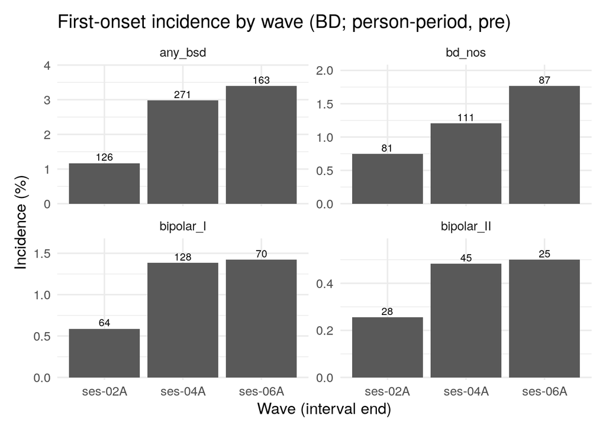

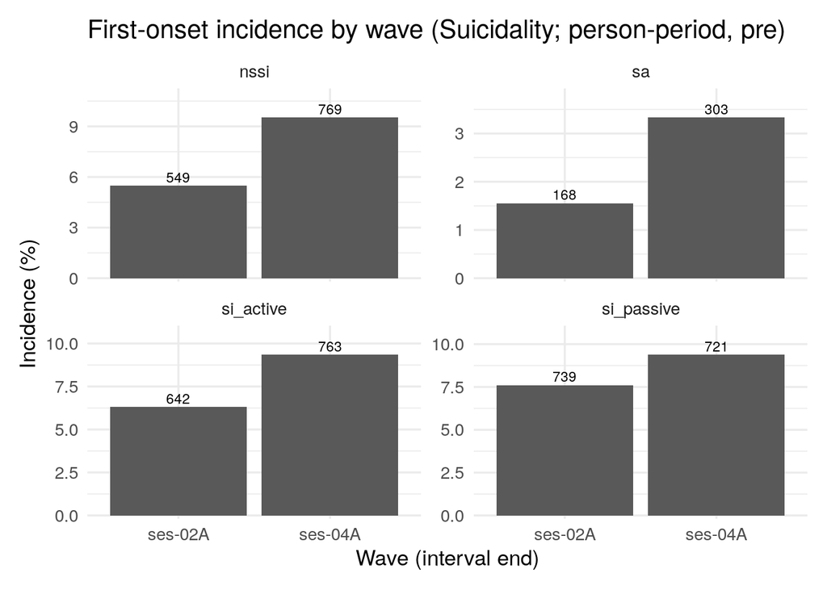

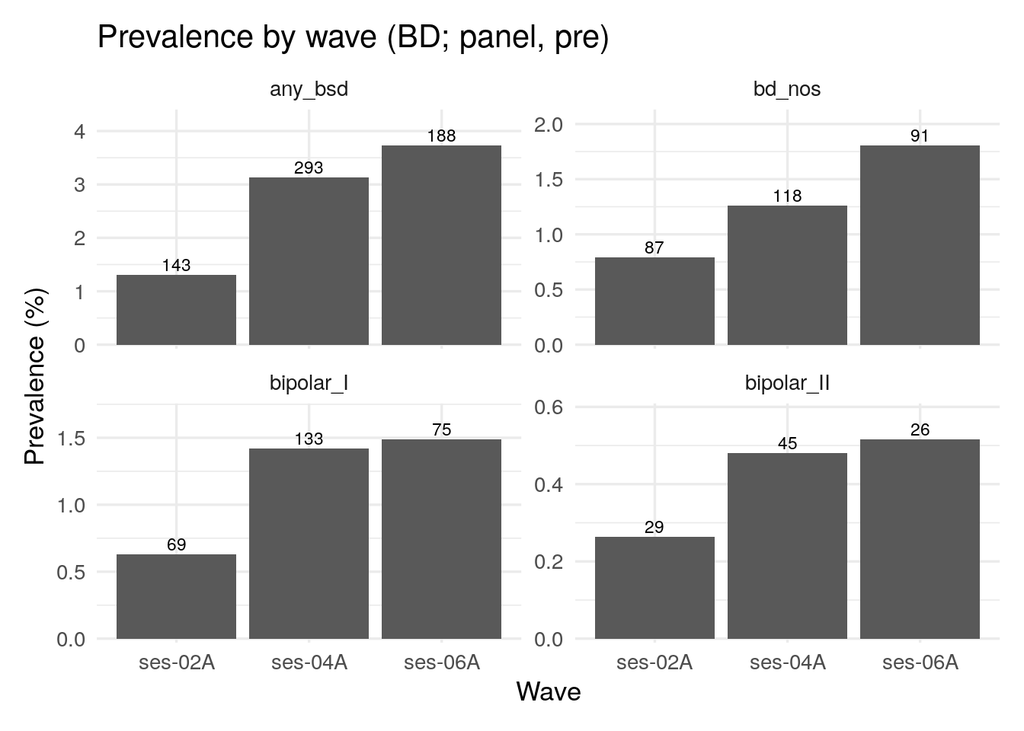

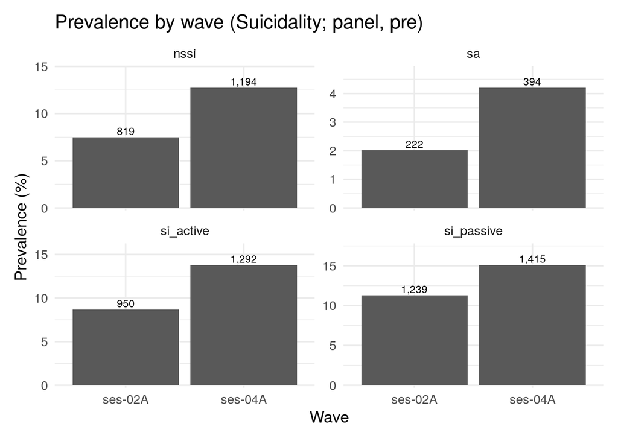

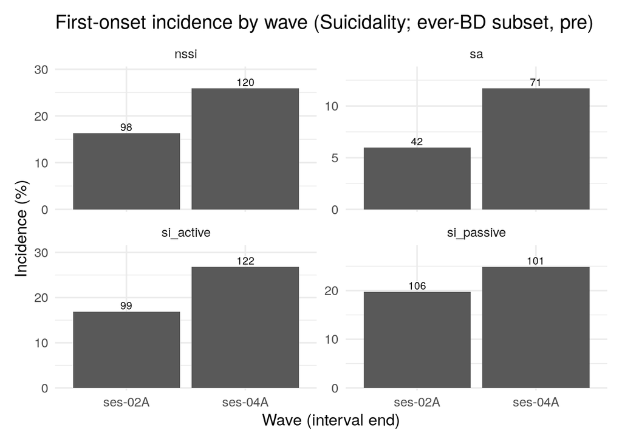

8.6.1 Dataset sizes (post-filter/model-ready)

| Dataset | Rows | IDs |
| --- | --- | --- |
| BD person-period (post) | 77336 | 8559 |
| Suicidality person-period (post) | 56247 | 8349 |
| BD panel (post) | 78508 | 8559 |
| Suicidality panel (post) | 78508 | 8559 |

8.6.2 BD person-period (post): one-onset rule

| n_subjects | n_multi_onsets | n_rows_after_onset | n_with_event_NA |
| --- | --- | --- | --- |
| 33891 | 0 | 0 | 0 |

8.6.3 Suicidality person-period (post): one-onset rule

| n_subjects | n_multi_onsets | n_rows_after_onset | n_with_event_NA |
| --- | --- | --- | --- |
| 31231 | 0 | 0 | 0 |

8.6.4 Baseline-positive excluded from at-risk time (post)

| Dataset | BaselineAtRiskViolations |
| --- | --- |
| BD person-period (post) | 0 |
| Suicidality person-period (post) | 0 |

8.6.5 BD (post): panel vs person-period - onsets & percentages

| outcome | wave | onsets_panel | at_risk_panel | perc_onset_panel | n_panel_obs | prev_panel | pos_panel | onsets_pp | n_pp_obs | perc_onset_pp | diff_onsets |
| --- | --- | --- | --- | --- | --- | --- | --- | --- | --- | --- | --- |
| any_bsd | ses-02A | 92 | 8253 | 0.0111475 | 8406 | 0.0126100 | 106 | 92 | 8253 | 0.0111475 | 0 |
| any_bsd | ses-04A | 205 | 7019 | 0.0292064 | 7215 | 0.0309078 | 223 | 205 | 7019 | 0.0292064 | 0 |
| any_bsd | ses-06A | 120 | 3819 | 0.0314218 | 4004 | 0.0342158 | 137 | 120 | 3819 | 0.0314218 | 0 |
| bd_nos | ses-02A | 55 | 8308 | 0.0066201 | 8406 | 0.0072567 | 61 | 55 | 8308 | 0.0066201 | 0 |
| bd_nos | ses-04A | 87 | 7099 | 0.0122552 | 7215 | 0.0128898 | 93 | 87 | 7099 | 0.0122552 | 0 |
| bd_nos | ses-06A | 59 | 3918 | 0.0150587 | 4004 | 0.0154845 | 62 | 59 | 3918 | 0.0150587 | 0 |
| bipolar_I | ses-02A | 49 | 8341 | 0.0058746 | 8406 | 0.0064240 | 54 | 49 | 8341 | 0.0058746 | 0 |
| bipolar_I | ses-04A | 92 | 7125 | 0.0129123 | 7215 | 0.0133056 | 96 | 92 | 7125 | 0.0129123 | 0 |
| bipolar_I | ses-06A | 56 | 3916 | 0.0143003 | 4004 | 0.0144855 | 58 | 56 | 3916 | 0.0143003 | 0 |
| bipolar_II | ses-02A | 22 | 8385 | 0.0026237 | 8406 | 0.0027361 | 23 | 22 | 8385 | 0.0026237 | 0 |
| bipolar_II | ses-04A | 36 | 7184 | 0.0050111 | 7215 | 0.0049896 | 36 | 36 | 7184 | 0.0050111 | 0 |
| bipolar_II | ses-06A | 20 | 3969 | 0.0050391 | 4004 | 0.0052448 | 21 | 20 | 3969 | 0.0050391 | 0 |

8.6.6a Suicidality (post): panel vs person-period - onsets & percentages

| outcome | wave | onsets_panel | at_risk_panel | perc_onset_panel | n_panel_obs | prev_panel | pos_panel | onsets_pp | n_pp_obs | perc_onset_pp | diff_onsets |
| --- | --- | --- | --- | --- | --- | --- | --- | --- | --- | --- | --- |
| nssi | ses-02A | 405 | 7670 | 0.0528031 | 8349 | 0.0679123 | 567 | 405 | 7670 | 0.0528031 | 0 |
| nssi | ses-04A | 568 | 6107 | 0.0930080 | 6966 | 0.1169968 | 815 | 568 | 6107 | 0.0930080 | 0 |
| sa | ses-02A | 124 | 8290 | 0.0149578 | 8349 | 0.0162894 | 136 | 124 | 8290 | 0.0149578 | 0 |
| sa | ses-04A | 217 | 6887 | 0.0315086 | 6966 | 0.0331611 | 231 | 217 | 6887 | 0.0315086 | 0 |
| si_active | ses-02A | 468 | 7798 | 0.0600154 | 8349 | 0.0791712 | 661 | 468 | 7798 | 0.0600154 | 0 |
| si_active | ses-04A | 577 | 6193 | 0.0931697 | 6966 | 0.1256101 | 875 | 577 | 6193 | 0.0931697 | 0 |
| si_passive | ses-02A | 560 | 7473 | 0.0749364 | 8349 | 0.1055216 | 881 | 560 | 7473 | 0.0749364 | 0 |
| si_passive | ses-04A | 527 | 5829 | 0.0904100 | 6966 | 0.1385300 | 965 | 527 | 5829 | 0.0904100 | 0 |

8.6.6b Suicidality (post, ever-BD): panel vs person-period - onsets & percentages

| outcome | wave | onsets_panel | at_risk_panel | perc_onset_panel | n_panel_obs | prev_panel | pos_panel | onsets_pp | n_pp_obs | perc_onset_pp | diff_onsets |
| --- | --- | --- | --- | --- | --- | --- | --- | --- | --- | --- | --- |
| nssi | ses-02A | 71 | 446 | 0.1591928 | 533 | 0.1894934 | 101 | 71 | 446 | 0.1591928 | 0 |
| nssi | ses-04A | 85 | 337 | 0.2522255 | 452 | 0.3008850 | 136 | 85 | 337 | 0.2522255 | 0 |
| sa | ses-02A | 29 | 527 | 0.0550285 | 533 | 0.0581614 | 31 | 29 | 527 | 0.0550285 | 0 |
| sa | ses-04A | 49 | 446 | 0.1098655 | 452 | 0.1084071 | 49 | 49 | 446 | 0.1098655 | 0 |
| si_active | ses-02A | 63 | 432 | 0.1458333 | 533 | 0.2045028 | 109 | 63 | 432 | 0.1458333 | 0 |
| si_active | ses-04A | 88 | 336 | 0.2619048 | 452 | 0.3230088 | 146 | 88 | 336 | 0.2619048 | 0 |
| si_passive | ses-02A | 71 | 405 | 0.1753086 | 533 | 0.2589118 | 138 | 71 | 405 | 0.1753086 | 0 |
| si_passive | ses-04A | 70 | 305 | 0.2295082 | 452 | 0.3340708 | 151 | 70 | 305 | 0.2295082 | 0 |

8.6.7 Cluster label presence (post-filter)

| Dataset | N_rows | Missing_cluster |
| --- | --- | --- |
| BD person-period (post) | 77336 | 0 |
| Suicidality person-period (post) | 56247 | 0 |
| BD panel (post) | 78508 | 0 |
| Suicidality panel (post) | 78508 | 0 |

8.6.8 Roll-up of key validation checks (pre vs post)

| Check | Value |
| --- | --- |
| PP one-onset violations (BD, pre) | 0 |
| PP one-onset violations (Suic, pre) | 0 |
| Baseline-at-risk violations (BD, pre) | 0 |
| Baseline-at-risk violations (Suic, pre) | 0 |
| Parity mismatches present (BD, pre) | 0 |
| Parity mismatches present (Suic, pre) | 0 |
| PP one-onset violations (BD, post) | 0 |
| PP one-onset violations (Suic, post) | 0 |
| Baseline-at-risk violations (BD, post) | 0 |
| Baseline-at-risk violations (Suic, post) | 0 |
| Parity mismatches present (BD, post) | 0 |
| Parity mismatches present (Suic, post) | 0 |

*Note on parity checks*. We compute first-onset events consistently across panel and person-period data using a cumulative prior positivity rule (seeded by baseline). Any minor “pre-filter” differences likely reflect different versions of the data (e.g., first onset in person-period data at later timepoints when it’s likely we’ll have more total occurrences than first onsets, etc.), and are expected.

In other words, in the “pre-filter” summary, panel counts onsets among all observed statuses at a wave, whereas the PP summary is driven by intervals with observed end-wave events and can be subtly different for a handful of participants whose earlier wave history (02A) is observed differently (e.g., 02A missing in panel for a given outcome while PP’s interval logic saw an onset at 02A; or vice-versa, panel has an observed status at 04A that PP’s interval deemed not “at-risk” because of earlier history).

“Post-filter” (i.e., filtering for data at timepoints of interest, with cluster labels, with complete outcome and covariate information, etc.) parity is our gating check, and is hopefully close to zero; any remaining single-cell differences reflect sparse/missing follow-ups and do not affect model-ready analyses